# 應用潛在語意分析於風傳媒政治新聞

YX.Wang

中文斷詞比英文斷詞複雜許多，多數的英文單字與單字間可以用空格隔開而不影響語意，停止詞 (stop words) 也單純許多。此篇嘗試裡，我利用在 python 上有名的中文斷詞套件 jieba 的 R 版本 jiebaR。本文大致可以分為三個步驟:

1.從風傳媒的政治新聞分類裡，建立我們的標題作為文件。

2.在開始斷詞前，盡可能地擴充詞庫。

3.斷詞後，轉換為詞彙-文件矩陣 (term-document matrix) 並開始進行潛在語意分析 (LSA; Latent Semantic Analysis)。

### 建立文件

從風傳媒的**政治類**新聞類別裡，爬取 100 頁的標題作為文件。(超過 100 頁文章似乎會開始重複。)

```r
title_all <- list()
pages <- 100

for( i in 1:pages){
title_temp <- read_html(paste0("http://www.storm.mg/category/118/",i)) %>%
  html_nodes(.,"#category_content .card_title") %>%
  html_text(.) %>%
  iconv(.,"UTF-8")

title_all <- append(title_all,title_temp)
}

title_all <- unique(title_all) %>%
  unlist() %>%
  .[!is.na(.)]
```

### 擴充自訂詞庫

在開始斷詞前，利用立法院公布的立法委員名單，以及從自由時報新聞網裡搜尋最近三個月 (2017/9/11 至 2017/12/10) 有關 “柯文哲” 的新聞關鍵字，來擴充jieba 的自訂詞庫，以加強 jieba 分詞器的效果。

值得一提的是，在建立本篇 notebook 時，我並沒有執行這段，因為我的目錄下已經有建立好的詞庫，且這段爬關鍵字的過程非常耗時。

```r
legi <- read_html("https://www.ly.gov.tw/Pages/List.aspx?nodeid=109") %>%
  html_nodes(.,".legislatorname") %>%
  html_text(.)

page_free <- 105
key_word_corpus <- list()

for( i in 1:page_free){
  free_temp <- read_html(paste0("http://news.ltn.com.tw/search/?keyword=%E6%9F%AF%E6%96%87%E5%93%B2&conditions=&SYear=2017&SMonth=09&SDay=11&EYear=2017&EMonth=12&EDay=10&page=",i)) %>%
    html_nodes(.,"#newslistul a.tit") %>%
    html_attr(.,"href") %>%
    sapply(.,function(x) paste0("http://news.ltn.com.tw/",x))

  for( j in 1:length(free_temp)){
    key_word_temp <- read_html(free_temp[j]) %>%
      html_nodes(.,".keyword a") %>%
      html_text(.)
    key_word_corpus <- append(key_word_corpus,key_word_temp)
  }
}

key_word_vector <- unlist(key_word_corpus) %>%
  unique()

writeLines(c(legi,key_word_vector),"C:/Users/YMM/Documents/R/win-library/3.4/jiebaRD/dict/user_dic_mod.utf8")
```

### 斷詞以及 LSA 前置準備

承上段，在開啟分詞器時，將停止詞庫與自訂詞庫都改為我們修改擴充的詞庫。這裡我們用的停止詞庫，是 jiebaR 的內建停止詞庫的繁體中文版本，可以在 python 版本 jieba 的 github 裡找到。

為了符合 `createTDM` 的格式，需要將 jiebaR 分好的 “斷句” 以 “斷詞” 的方式表達。

```r
cut <- worker(stop_word="C:/Users/YMM/Documents/R/win-library/3.4/jiebaRD/dict/user_stop.utf8",
              user="C:/Users/YMM/Documents/R/win-library/3.4/jiebaRD/dict/user_dic_mod.utf8")
cut$bylines <- TRUE

jie_seg <- cut[title_all] %>%
  sapply(., FUN=paste, collapse = " ") %>%
  gsub("\\d","",.)

termdoc_mat <- as.matrix(createTDM(jie_seg))
```

### LSA

在進行 SVD 分解前的最後一個步驟，需先進行 TF-IDF 的詞頻/檔頻加權，來避免後續分析傾向更長的文檔，也避免浮濫的語詞佔太高的重要性。

關於 TF 以及 IDF，其實都各有不只一種計算方式，在這裡採用的是最一般的形式，且經過多次測試發現結果差異並不大。

LSA 事實上就是一個透過 SVD 分解降低原始 term-document matrix 維度的方法，透過降低維度不僅可以減少資料的儲存量，也可以藉由把奇異值 (singular value) 太小的概念剔除，以降低模型*雜訊*，獲得更好的索引結果。

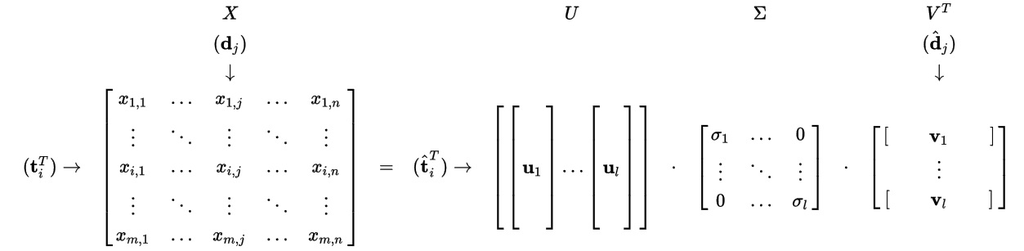

```r
include_graphics("C:/Users/YMM/Desktop/SVD.jpg")
```

透過分解後的
$$\Sigma_{k} \hat{t_{i}}$$
，可以得到 reduced term vector，
$$\Sigma_{k} \hat{d_{j}}$$
則能得到 reduced document vector。後續分析需要透過這兩個縮減過後的向量。

其中，k 是縮減後的維度，在此，我們選擇 k 的方式，是採取 “所有奇異值總和的前 50%” 作為縮減維度。

```r
td_mat_lsa <- lw_tf(termdoc_mat) * gw_idf(termdoc_mat)
lsa_space <- lsa(td_mat_lsa,dim=dimcalc_share(0.5))

term_vec <- lsa_space$tk*lsa_space$sk
doc_vec <- lsa_space$dk*lsa_space$sk
```

### 字詞相關性

常見用以衡量字詞間相關程度的方法為向量兩兩之間的角度餘弦 (cosin)，在此我們計算 reduced term vector 的 cosine similarity，並找出 row 為 “柯文哲” 的前 30 大值，就是與 “柯文哲” 該詞彙在語意空間最相關的詞彙。

```r
term_Sim_lsa<- cosine(t(term_vec))
sort(term_Sim_lsa["柯文哲",],decreasing=T)[1:30]
```

[output not shown]

### 結論

我們以 LSA 得出 reduced term/doc. vector 後，該兩向量後續還可以利用 cluster 的相關方法 (如: K-means, EM Clustering..等) ，將各詞彙分群，找出一組組相關程度高的字詞。另外，許多篇關於 LSA 分析的文章都會將維度壓縮至二維至三維以方便視覺化 term-term/term-doc. 的相近程度，但我認為與本篇“欲找出與特定詞彙相關字詞”的目標不同，故本篇並未列出。

除此之外，常見用於語意分析的進階模型有 Probabilistic LSA 以及 Latent Dirichlet allocation，或許日後有機會補足該模型原理與應用!